# ADSP 32018 IP01 (Autumn 2023) Natural Language Processing and Cognitive Computing

### Final Project Data Science

### Due: Tue Dec 7, 2023 11:59pm

#### Mia Song

In March of 2023, Goldman Sachs published a reportLinks to an external site., indicating that ~25% of the tasks in US and Europe can be automated using AI. However, as you can see in this visualizationLinks to an external site., not all industries will be affected equally. According to the report, certain jobs, like office tasks, legal, architecture and social sciences have a potential for 30%+ automation, while positions like construction, installation and building maintenance are going to be largely unaffected.

You can also see supporting evidence in the Facebook Research paperLinks to an external site., which highlights Moravec’s paradox, the thesis that the hardest problems in AI involve sensorimotor skills, not abstract thought or reasoning, which coincide with Goldman Sachs predictions.

While both of these papers are very impressive, they also heavily influenced by the recent advances in Large Language Models (LLMs). For this final project I have prepared a collection of ~200K news articles (about 900 MB) articles on our favorite topics: Data Science, Machine Learning and Artificial Intelligence, and I want you to identify what industries and job lines are going to be most impacted by the AI over the next several years, based on the information you can disseminate from this text corpus.

**The objective of your final project is to identify what types of tasks and jobs are most likely to see the biggest impact from AI by extracting meaningful insights from unstructured text. Your goal is to provide actionable recommendations on what can be done with AI to automate the jobs and / or improve employee productivity. Please pay attention to the introduction of novel technologies and algorithms, such as AI for image generation and Conversational AI, as they represent the entire paradigm shift in adoption of AI technologies and data science in general.**

# Import Dependencies

```python
# pip install pyarrow
# pip install pyLDAvis
# pip install textblob
# pip install spacy
# pip install pandarallel
# pip install pyarrow
# pip install ktrain
# pip install bokeh
# pip install squarify
```

```python
import os
import time
import math
import re
from pprint import pprint
from textblob import TextBlob
import pandas as pd
import numpy as np
import matplotlib.pyplot as plt
import seaborn as sns
import string

import nltk as nltk
from nltk.corpus import stopwords
from nltk.stem.wordnet import WordNetLemmatizer
from nltk.corpus import stopwords
from wordcloud import WordCloud
from nltk.corpus import wordnet
from nltk.stem import WordNetLemmatizer
import nltk
import spacy
import multiprocessing
import string
import squarify

import gensim
from gensim import corpora, models
from gensim.models.ldamulticore import LdaMulticore
from gensim.utils import simple_preprocess
from gensim.models import CoherenceModel
from pandarallel import pandarallel

import warnings

warnings.simplefilter('once')
warnings.simplefilter('ignore')
warnings.filterwarnings("ignore", category=FutureWarning)
warnings.filterwarnings("ignore", category=DeprecationWarning)
warnings.filterwarnings(action='ignore', category=UserWarning, module='gensim')
```

Loading BokehJS ...

```python
pd.set_option('display.max_rows', 100)
pd.set_option('display.max_columns', None)
pd.set_option('display.max_colwidth', 500)
```

```python
num_processors = multiprocessing.cpu_count()
num_processors

workers = num_processors-1

print(f'Using {workers} workers')
```

```
Using 15 workers
```

```python
pandarallel.initialize(nb_workers=workers, use_memory_fs=False)
```

```
INFO: Pandarallel will run on 15 workers.
INFO: Pandarallel will use standard multiprocessing data transfer (pipe) to transfer data between the main process and workers.
```

# 1. Import Data

```python
%%time
news = pd.read_parquet('https://storage.googleapis.com/msca-bdp-data-open/news_final_project/news_final_project.parquet', engine='pyarrow')
```

```
CPU times: user 7.87 s, sys: 4.43 s, total: 12.3 s
Wall time: 25.7 s
```

```python
news.columns
```

```
Index(['url', 'date', 'language', 'title', 'text'], dtype='object')
```

```python
news.shape
```

```
(199677, 5)
```

### Key Takeaways

- Our data sampling revealed that the titles of news articles were typically derived from the first few words.
- For further analysis, we will focus exclusively on the text content.
- After visually inspecting several articles, we identified several elements that require removal for cleaner data: 1) Newlines, 2) Tabs, 3) Remnants from web crawls, 4) Emojis, 5) Web links, and 6) Email addresses.

```python
news.head(3)
```

|  | url | date | language | title | text |
| --- | --- | --- | --- | --- | --- |
| 0 | http://galusaustralis.com/2020/02/486473/legaltech-artificial-intelligence-market-2019-technology-advancement-and-future-scope-casetext-inc-catalyst-repository-systems-ebrevia/ | 2020-02-26 | en | LegalTech Artificial Intelligence Market 2019 Technology Advancement and Future Scope – Casetext Inc., Catalyst Repository Systems, eBREVIA – Galus Australis | LegalTech Artificial Intelligence Market 2019 Technology Advancement and Future Scope – Casetext Inc., Catalyst Repository Systems, eBREVIA – Galus Australis \n\nGalus Australis\n\nBusinessGeneral New… |
| 1 | http://spaceref.com/astronomy/observation-simulation-and-ai-join-forces-to-reveal-a-clear-universe.html | 2021-07-05 | en | Observation, Simulation, And AI Join Forces To Reveal A Clear Universe - SpaceRef | \n\nObservation, Simulation, And AI Join Forces To Reveal A Clear Universe - SpaceRef\n\n \nHome \|\nNASA Watch\nSpaceRef Business\nAstrobiology Web\nAdvertising\nAdd an Event\nSign up for our Daily N… |
| 2 | http://usweekly.com/news/17/40964/Artificial-intelligence-yields-new-antibiotic.html | 2020-02-23 | en | Artificial intelligence yields new antibiotic - USweekly | \n\n\nArtificial intelligence yields new antibiotic - USweekly\nSunday, 23 February 2020\nSend search form\n \n\nTodays news\nWorld\nU.S. National\nPolitics\nBusiness\nTechnology\nSports\nEntertainme… |

# 2. Clean and Prepare Data

## 2.1. Select English-Language News Articles

- Preliminary review indicates that the news article dataset consists of content in English.

```python
news = news[news['language'] == 'en']
```

```python
news['language'].value_counts()
```

```
language
en    199677
Name: count, dtype: int64
```

```python
news.shape
```

```
(199677, 5)
```

```python
news.info()
```

```
<class 'pandas.core.frame.DataFrame'>
RangeIndex: 199677 entries, 0 to 199676
Data columns (total 5 columns):
 #   Column    Non-Null Count   Dtype
---  ------    --------------   -----
 0   url       199677 non-null  object
 1   date      199677 non-null  object
 2   language  199677 non-null  object
 3   title     199677 non-null  object
 4   text      199677 non-null  object
dtypes: object(5)
memory usage: 7.6+ MB
```

## 2.2. Convert Data Types

- The 'date' column should be treated as a datetime type, not an object type.

```python
news['date'] = pd.to_datetime(news['date'])
news.dtypes
```

```
url                 object
date        datetime64[ns]
language            object
title               object
text                object
dtype: object
```

- Create additional columns with detailed date information to facilitate future analyses that track trends and developments over time.

```python
news['year'] = news['date'].dt.year
news['month'] = news['date'].dt.month
news['day'] = news['date'].dt.day
```

## 2.3. Remove Nulls (if applicable)

- There are no null values in the news data.

```python
news.isnull().sum()
```

```
url         0
date        0
language    0
title       0
text        0
year        0
month       0
day         0
dtype: int64
```

## 2.4. Clean Text

```python
nltk.download('stopwords')
nltk.download('punkt')
```

```
True
```

- Stopwords Removal: Utilized NLTK to filter out common English stopwords.
- Regex Cleaning: Emojis, HTML tags, scripts, styles, comments, Web links and email addresses.

```python
# Set stopwords
stopwords = set(nltk.corpus.stopwords.words('english'))

# Regex patterns
emoji_pattern = re.compile("["
                           u"\U0001F600-\U0001F64F"  # emoticons
                           u"\U0001F300-\U0001F5FF"  # symbols & pictographs
                           u"\U0001F680-\U0001F6FF"  # transport & map symbols
                           u"\U0001F1E0-\U0001F1FF"  # flags (iOS)
                           "]+", flags=re.UNICODE)

html_remnants_pattern = re.compile(r'<[^>]+>')
script_pattern = re.compile(r'<script[^>]*>.*?</script>', re.DOTALL)
style_pattern = re.compile(r'<style[^>]*>.*?</style>', re.DOTALL)
comment_pattern = re.compile(r'<!--.*?-->', re.DOTALL)
web_link_pattern = re.compile(r'https?://\S+|www\.\S+')
email_pattern = re.compile(r'\S+@\S+')
```

#### 1. Remove extra space infront of punctuations

```python
def smart_join(tokens):
    text = ''
    for i, token in enumerate(tokens):
        if token in [".", ",", ";", ":", "!", "?"] and i > 0:
            text = text.rstrip() + token + " "
        else:
            text += token + " "
    return text.strip()
```

#### 2. Minimize data cleaning for NER purpose

#### We carried out the first basic text cleansing, notably excluding the conversion to **lowercase** for NER.

#### Basic Principles in Text Cleaning for NER

1. Case Sensitivity:
   - Standard Cleaning: Text is often converted to lowercase to maintain consistency and simplify tasks like topic modeling or word frequency analysis.
   - NER Cleaning: The case is retained since proper nouns, especially names of people and places, often start with capital letters. Converting to lowercase can reduce the accuracy of entity detection.
2. Stopwords Removal:
   - Standard Cleaning: Stopwords are frequently removed to reduce dimensionality and noise.
   - NER Cleaning: It's often better to retain stopwords as removing them can disrupt entity phrases like "The United States of America."
3. Tokenization:
   - Standard Cleaning: Text might be tokenized into individual words for analyses like word clouds or bag-of-words models.
   - NER Cleaning: Sentences should be kept intact or tokenized as whole sentences. Context around a word can be crucial for determining if it's an entity.
4. Special Characters and Punctuation:
   - Standard Cleaning: These are often removed to simplify text.
   - NER Cleaning: Some special characters or punctuation might be retained, especially if they can denote entities (e.g., "$" for monetary values).
5. Stemming and Lemmatization:
   - Standard Cleaning: Words are often stemmed or lemmatized to reduce them to their base or root form.
   - NER Cleaning: Avoid stemming and lemmatization, as entities need to be in their original form for accurate recognition.
6. Context Preservation:
   - Standard Cleaning: Depending on the analysis, context might not always be critical.
   - NER Cleaning: Preserving the context is crucial, as surrounding words can influence the type and accuracy of entity recognition.
7. Handling Numbers:
   - Standard Cleaning: Numbers might be removed, especially if the focus is on textual content.
   - NER Cleaning: Numbers should be preserved, especially if dates, amounts, or other numerical entities are relevant.

```python
# Function to preprocess the news article
def clean_news_for_ner(text):
    # Remove HTML remnants, scripts, styles, comments, web links, and emails
    text = re.sub(html_remnants_pattern, '', text)
    text = re.sub(script_pattern, '', text)
    text = re.sub(style_pattern, '', text)
    text = re.sub(comment_pattern, '', text)
    text = re.sub(web_link_pattern, '', text)
    text = re.sub(email_pattern, '', text)

    # Remove newlines, tabs, and emojis
    text = text.replace('\n', ' ').replace('\r', '').replace('\t', ' ')
    text = re.sub(emoji_pattern, '', text)

    # Remove emojis and other special characters except alphanumeric, spaces, periods, and commas
    text = re.sub(r'[^\w\s.,]', ' ', text)

    # Normalize space (removing extra spaces)
    text = re.sub(r'\s+', ' ', text).strip()

    # Tokenize the text
    tokens = nltk.tokenize.word_tokenize(text)

    # Further cleaning with tokens
    tokens = [word for word in tokens if len(word) < 20]
    tokens = [word for word in tokens if not word.isnumeric()]

    # Join tokens back into a string
    # cleaned_text = ' '.join(tokens)
    cleaned_text = smart_join(tokens)

    return cleaned_text
```

```python
%%time
news['text_ner'] = news['text'].parallel_apply(clean_news_for_ner)
```

```
CPU times: user 6.82 s, sys: 11 s, total: 17.8 s
Wall time: 3min 43s
```

```python
news[['text', 'text_ner']].sample(3, random_state = 42)
```

|  | text | text_ner |
| --- | --- | --- |
| 56528 | Week 4 Introduction - AI and Society \| Coursera\n ExploreOnline DegreesFind your New CareerFor EnterpriseFor UniversitiesBrowseTop CoursesLog InJoin for FreeListWeek 4 IntroductionLoading...AI For Ev… | Week Introduction AI and Society Coursera ExploreOnline DegreesFind your New CareerFor EnterpriseFor CoursesLog InJoin for FreeListWeek IntroductionLoading ... AI For StarFilled StarFilled StarFilled … |
| 69027 | \nThe Aging of Disney Princesses: Exploring the Impact of Artificial Intelligence - Top Buzz Trends\n\n \n\n \n \nNo Result \n\n View All Result \n \n \n\n \n \nEntertainment\nBusiness\nGaming\n\nTech… | The Aging of Disney Princesses Exploring the Impact of Artificial Intelligence Top Buzz Trends No Result View All Result Entertainment Business Gaming Tech Crypto More Netflix Amazon Prime Max Celebri… |
| 29208 | \nPolicymakers in D.C. Don’t Appear To Be Focused On Artists’ AI Concerns – ARTnews.com\n \n\n \n \n \n \n\n \n\n\n \n\n\t\t\tSkip to main content\t\t\n\n\tFollow Us\n\nIcon Link\nPlus Icon\nIcon Link… | Policymakers in D.C. Don t Appear To Be Focused On Artists AI Concerns ARTnews.com Skip to main content Follow Us Icon Link Plus Icon Icon Link Plus Icon Icon Link Plus Icon Icon Link Plus Icon Icon L… |

#### 3. Add further data cleansing for other NLP tasks

```python
# Function to preprocess text for sentiment analysis
def clean_news(text):

    # Tokenize the text
    tokens = nltk.tokenize.word_tokenize(text)

    # Apply length filters
    tokens = [word for word in tokens if len(word) > 1]

    # Filter out non-alphabetic tokens
    tokens = [word for word in tokens if word.isalpha()]

    # Lowercase the tokens for uniformity
    tokens = [word.lower() for word in tokens]

    # Remove stopwords
    tokens = [word for word in tokens if word not in stopwords]

    # Join tokens back into a string
    cleaned_text = ' '.join(tokens)

    return cleaned_text
```

```python
%%time
news['text_cleaned'] = news['text_ner'].parallel_apply(clean_news)
```

```
CPU times: user 4.1 s, sys: 9.27 s, total: 13.4 s
Wall time: 2min 59s
```

```python
news[['text', 'text_ner', 'text_cleaned']].sample(3, random_state = 42)
```

|  | text | text_ner | text_cleaned |
| --- | --- | --- | --- |
| 56528 | Week 4 Introduction - AI and Society \| Coursera\n ExploreOnline DegreesFind your New CareerFor EnterpriseFor UniversitiesBrowseTop CoursesLog InJoin for FreeListWeek 4 IntroductionLoading...AI For Ev… | Week Introduction AI and Society Coursera ExploreOnline DegreesFind your New CareerFor EnterpriseFor CoursesLog InJoin for FreeListWeek IntroductionLoading ... AI For StarFilled StarFilled StarFilled … | week introduction ai society coursera exploreonline degreesfind new careerfor enterprisefor courseslog injoin freelistweek introductionloading ai starfilled starfilled starfilled starfilled ratings st… |
| 69027 | \nThe Aging of Disney Princesses: Exploring the Impact of Artificial Intelligence - Top Buzz Trends\n\n \n\n \n \nNo Result \n\n View All Result \n \n \n\n \n \nEntertainment\nBusiness\nGaming\n\nTech… | The Aging of Disney Princesses Exploring the Impact of Artificial Intelligence Top Buzz Trends No Result View All Result Entertainment Business Gaming Tech Crypto More Netflix Amazon Prime Max Celebri… | aging disney princesses exploring impact artificial intelligence top buzz trends result view result entertainment business gaming tech crypto netflix amazon prime max celebrity news movies tv shows pa… |
| 29208 | \nPolicymakers in D.C. Don’t Appear To Be Focused On Artists’ AI Concerns – ARTnews.com\n \n\n \n \n \n \n\n \n\n\n \n\n\t\t\tSkip to main content\t\t\n\n\tFollow Us\n\nIcon Link\nPlus Icon\nIcon Link… | Policymakers in D.C. Don t Appear To Be Focused On Artists AI Concerns ARTnews.com Skip to main content Follow Us Icon Link Plus Icon Icon Link Plus Icon Icon Link Plus Icon Icon Link Plus Icon Icon L… | policymakers appear focused artists ai concerns skip main content follow us icon link plus icon icon link plus icon icon link plus icon icon link plus icon icon link plus icon icon link plus icon news… |

#### 5. Lemmatize texts

```python
nltk.download('averaged_perceptron_tagger')
nltk.download('wordnet')
```

```
True
```

```python
# Function to determine the WordNet Part of Speech (PoS) tag for lemmatization
def get_wordnet_pos(word):
    """Map POS tag to first character lemmatize() accepts"""
    tag = nltk.pos_tag([word])[0][1][0].upper()
    tag_dict = {"J": wordnet.ADJ,
                "N": wordnet.NOUN,
                "V": wordnet.VERB,
                "R": wordnet.ADV}

    return tag_dict.get(tag, wordnet.NOUN)

# Function to lemmatize text (assuming it's already in lowercase)
def lemmatize_text(text):
    # Tokenize the text into words
    words = nltk.word_tokenize(text)

    # Initialize WordNetLemmatizer
    lemmatizer = WordNetLemmatizer()

    # Lemmatize each word using the appropriate part of speech
    lemmatized_words = [lemmatizer.lemmatize(word, get_wordnet_pos(word)) for word in words]

    # Join the lemmatized words back into a string
    lemmatized_text = ' '.join(lemmatized_words)

    return lemmatized_text
```

```python
%%time
news['text_lemm'] = news['text_cleaned'].parallel_apply(lemmatize_text)
```

```
CPU times: user 3.85 s, sys: 9.3 s, total: 13.1 s
Wall time: 42min 5s
```

```python
news[['text', 'text_ner', 'text_cleaned', 'text_lemm']].sample(3, random_state = 42)
```

|  | text | text_ner | text_cleaned | text_lemm |
| --- | --- | --- | --- | --- |
| 56528 | Week 4 Introduction - AI and Society \| Coursera\n ExploreOnline DegreesFind your New CareerFor EnterpriseFor UniversitiesBrowseTop CoursesLog InJoin for FreeListWeek 4 IntroductionLoading...AI For Ev… | Week Introduction AI and Society Coursera ExploreOnline DegreesFind your New CareerFor EnterpriseFor CoursesLog InJoin for FreeListWeek IntroductionLoading ... AI For StarFilled StarFilled StarFilled … | week introduction ai society coursera exploreonline degreesfind new careerfor enterprisefor courseslog injoin freelistweek introductionloading ai starfilled starfilled starfilled starfilled ratings st… | week introduction ai society coursera exploreonline degreesfind new careerfor enterprisefor courseslog injoin freelistweek introductionloading ai starfilled starfilled starfilled starfilled rating stu… |
| 69027 | \nThe Aging of Disney Princesses: Exploring the Impact of Artificial Intelligence - Top Buzz Trends\n\n \n\n \n \nNo Result \n\n View All Result \n \n \n\n \n \nEntertainment\nBusiness\nGaming\n\nTech… | The Aging of Disney Princesses Exploring the Impact of Artificial Intelligence Top Buzz Trends No Result View All Result Entertainment Business Gaming Tech Crypto More Netflix Amazon Prime Max Celebri… | aging disney princesses exploring impact artificial intelligence top buzz trends result view result entertainment business gaming tech crypto netflix amazon prime max celebrity news movies tv shows pa… | age disney princess explore impact artificial intelligence top buzz trend result view result entertainment business game tech crypto netflix amazon prime max celebrity news movie tv show paramount dis… |
| 29208 | \nPolicymakers in D.C. Don’t Appear To Be Focused On Artists’ AI Concerns – ARTnews.com\n \n\n \n \n \n \n\n \n\n\n \n\n\t\t\tSkip to main content\t\t\n\n\tFollow Us\n\nIcon Link\nPlus Icon\nIcon Link… | Policymakers in D.C. Don t Appear To Be Focused On Artists AI Concerns ARTnews.com Skip to main content Follow Us Icon Link Plus Icon Icon Link Plus Icon Icon Link Plus Icon Icon Link Plus Icon Icon L… | policymakers appear focused artists ai concerns skip main content follow us icon link plus icon icon link plus icon icon link plus icon icon link plus icon icon link plus icon icon link plus icon news… | policymakers appear focus artist ai concern skip main content follow u icon link plus icon icon link plus icon icon link plus icon icon link plus icon icon link plus icon icon link plus icon newslette… |

#### 6. Remove press names from news titles

- For news titles, we specifically remove media names, taking advantage of their identifiable patterns.
- The analysis of news titles alone might enable a preliminary LDA (Latent Dirichlet Allocation) process, facilitating quicker insights.

```python
# Function to preprocess the news article
def clean_news_title_for_ner(text):
    # Remove parts of text after '-', '–', or '|' to remove media company's name
    text = re.sub(r'\s[-–|]\s.*$', '', text)

    # Remove HTML remnants, scripts, styles, comments, web links, and emails
    text = re.sub(html_remnants_pattern, '', text)
    text = re.sub(script_pattern, '', text)
    text = re.sub(style_pattern, '', text)
    text = re.sub(comment_pattern, '', text)
    text = re.sub(web_link_pattern, '', text)
    text = re.sub(email_pattern, '', text)

    # Remove newlines, tabs, and emojis
    text = text.replace('\n', ' ').replace('\r', '').replace('\t', ' ')
    text = re.sub(emoji_pattern, '', text)

    # Remove emojis and other special characters except alphanumeric, spaces, periods, and commas
    text = re.sub(r'[^\w\s.,]', ' ', text)

    # Normalize space (removing extra spaces)
    text = re.sub(r'\s+', ' ', text).strip()

    # Tokenize the text
    tokens = nltk.tokenize.word_tokenize(text)

    # Further cleaning with tokens
    tokens = [word for word in tokens if len(word) < 20]
    tokens = [word for word in tokens if not word.isnumeric()]

    # Join tokens back into a string
    # cleaned_text = ' '.join(tokens)
    cleaned_text = smart_join(tokens)

    return cleaned_text
```

```python
%%time
news['title_ner'] = news['title'].parallel_apply(clean_news_title_for_ner)
```

```
CPU times: user 151 ms, sys: 2.04 s, total: 2.19 s
Wall time: 5.99 s
```

```python
%%time
news['title_cleaned'] = news['title_ner'].parallel_apply(clean_news)
```

```
CPU times: user 130 ms, sys: 2.15 s, total: 2.28 s
Wall time: 5.26 s
```

```python
%%time
news['title_lemm'] = news['title_cleaned'].parallel_apply(lemmatize_text)
```

```
CPU times: user 122 ms, sys: 2.21 s, total: 2.33 s
Wall time: 37.7 s
```

```python
news[['title', 'title_ner', 'title_cleaned', 'title_lemm']].sample(3, random_state = 42)
```

|  | title | title_ner | title_cleaned | title_lemm |
| --- | --- | --- | --- | --- |
| 198261 | Prosecutors in all 50 states urge Congress to strengthen tools to fight AI child sexual abuse images | Prosecutors in all states urge Congress to strengthen tools to fight AI child sexual abuse images | prosecutors states urge congress strengthen tools fight ai child sexual abuse images | prosecutor state urge congress strengthen tool fight ai child sexual abuse image |
| 31723 | These tech giants are at the White House today to talk about the risks of AI \| TPR | These tech giants are at the White House today to talk about the risks of AI | tech giants white house today talk risks ai | tech giant white house today talk risk ai |
| 105612 | A philanthropic drive to aid Black women is gaining - One News Page | A philanthropic drive to aid Black women is gaining | philanthropic drive aid black women gaining | philanthropic drive aid black woman gain |

## 2.5. Remove Duplicates (if applicable)

```python
news['title_cleaned'].duplicated().sum() / len(news)
```

```
0.44358138393505514
```

- Consequently, we chose to eliminate entries from our dataset in cases where duplicate news articles were identified.

```python
news['text_cleaned'].duplicated().sum() / len(news)
```

```
0.007331840923090791
```

```python
news[['text_cleaned', 'title_cleaned']].duplicated().sum() / len(news)
```

```
0.007331840923090791
```

```python
# Remove duplicate rows based on 'text_cleaned' column
# The keep='first' argument ensures that only the first occurrence is kept, and the subsequent duplicates are removed.
news = news.drop_duplicates(subset='text_cleaned', keep='first')
```

```python
news.shape # (199677, 5)
```

```
(198213, 14)
```

```python
news[['title_cleaned', 'text_cleaned']].sample(10, random_state = 42)
```

|  | title_cleaned | text_cleaned |
| --- | --- | --- |
| 48615 | wondershare edrawmax openai chatgpt integration launches unveiling new ai powered diagramming tools enhanced productivity | wondershare edrawmax openai chatgpt integration launches unveiling new ai powered diagramming tools enhanced productivity skip pledge ushomedownload appsshare picsrecent videoswatch forecastriver stag… |
| 29696 | rosebud | rosebud fast track personal growth ai product huntproductscoming sooncheck launches coming soonproduct questionsanswer interesting questionslaunch archivemost loved launches best product hunt everyday… |
| 114790 | cheaters hacked ai bot beat rocket league elite | cheaters hacked ai bot beat rocket league elite wired skip main contentopen navigation menumenustory savedto revist article visit profile view saved alertcheaters hacked ai bot beat rocket league save… |
| 122125 | call centers could turn artificial intelligence face flight madness | call centers could turn artificial intelligence face flight madness javascript required site display correctly search news latest news latest news coronavirus recovery spirt airlines takeover breaking… |
| 150391 | google shares drop billion new ai chatbot makes mistake | google shares drop billion new ai chatbot makes mistake search query show search home news politics sports health arts culture economy hunting fishing education science environment public safety kusko… |
| 49285 | bias ai impacts women people colour troy media | bias ai impacts women people colour troy media friend facebook follow twitter search site search site type keyword hit enter close home arts entertainment books business entrepreneurs small business f… |
| 189610 | ex facebook data scientist alleges social network fed capitol riot chooses profits safety | ex facebook data scientist alleges social network fed capitol riot chooses profits safety newsbreaksign arttv seriesbooks dancebehind viral videosperforming artstv musichip healthhealth servicesmental… |
| 63691 | european ai drug discovery market outlook profiles key players including atomwise deep genomics google ibm insilico medicine verge genomics amongst others | european ai drug discovery market outlook profiles key players including atomwise deep genomics google ibm insilico medicine verge genomics amongst others mehr auf fnalle newsrubrikenaktien im blickpu… |
| 63661 | cerence present evercore isi new mobility ai forum | cerence present evercore isi new mobility ai forum us works testimonials video tutorials editorial guidelines faqs contact pricing distribution pricing comparison chart distribution overview tv radio … |
| 182217 | zen media launches first generative ai tool predict newsworthiness | zen media launches first generative ai tool predict newsworthiness skip contentweatherwatch newsdigital news deskcontestsadopt petsmall business summerway west news desk camswatch newsdigital news des… |

## 2.6. Discard irrelevant articles

- Discarding irrelevant articles is a part of the data cleaning process. It is essential to perform this before you engage in any kind of text analysis, including LDA (Latent Dirichlet Allocation), to ensure that your dataset only contains relevant information that pertains to your study's focus.

```python
# Function to check if text contains any of the specified keywords
def contains_keywords(text, keywords):
    # Create a regular expression pattern with all keywords, case insensitive
    pattern = re.compile('|'.join(re.escape(keyword) for keyword in keywords), re.IGNORECASE)
    # Search the text for any occurrence of the pattern
    return bool(pattern.search(text))

# List of keywords
keywords = ["Artificial Intelligence", "AI", "Machine Learning", "ML", "Data Science",
            "Deep Learning", "Neural Networks", "Predictive Analytics",
            "Natural Language Processing", "NLP", "Computer Vision", "Robotics",
            "Automation", "Big Data", "Analytics", "Algorithm",
            "Supervised Learning", "Unsupervised Learning", "Reinforcement Learning",
            "GPT", "ChatGPT"]
```

```python
%%time
len(news[news['text_cleaned'].parallel_apply(lambda text: contains_keywords(text, keywords))]) # (198213, 14)
```

```
CPU times: user 1.16 s, sys: 4.25 s, total: 5.41 s
Wall time: 9.69 s
```

```
198064
```

```python
news = news[news['text_cleaned'].parallel_apply(lambda text: contains_keywords(text, keywords))]
```

## 2.7. Count words from news titles and texts

```python
%%time
news['title_word_count'] = news['title_lemm'].parallel_apply(lambda x : len(x.split()))
```

```
CPU times: user 54.1 ms, sys: 2.36 s, total: 2.41 s
Wall time: 2.64 s
```

```python
%%time
news['text_word_count'] = news['text_lemm'].parallel_apply(lambda x : len(x.split()))
```

```
CPU times: user 986 ms, sys: 4.25 s, total: 5.24 s
Wall time: 10 s
```

```python
news[['title_lemm', 'title_word_count', 'text_lemm', 'text_word_count']].sample(3, random_state = 42)
```

|  | title_lemm | title_word_count | text_lemm | text_word_count |
| --- | --- | --- | --- | --- |
| 198261 | prosecutor state urge congress strengthen tool fight ai child sexual abuse image | 12 | prosecutor state urge congress strengthen tool fight ai child sexual abuse image skip contentcommunity coverage tourhome promedically speakingbest westchampions agback appscovid newstexasnew tiplatest… | 618 |
| 31723 | tech giant white house today talk risk ai | 8 | tech giant white house today talk risk ai tpr search query show search news art culture bioscience medicine border immigration business criminal justice education environment government politics milit… | 1158 |
| 105612 | philanthropic drive aid black woman gain | 6 | philanthropic drive aid black woman gain one news page skip main content one news page trust news discovery since one news page trust news discovery since global edition wednesday april home one news … | 903 |

```python
from google.cloud import storage
```

```python
news.to_parquet('news_cleaned.parquet')
```

```python
# Google Cloud Storage details
bucket_name = 'nlp-final'
file_path = 'news_cleaned.parquet'  # This is the name the file will have in GCS
local_file_path = 'news_cleaned.parquet'  # Path to the local file you just saved

# Create a GCS Client
storage_client = storage.Client()

# Get the bucket
bucket = storage_client.get_bucket(bucket_name)

# Create a blob object from the filepath
blob = bucket.blob(file_path)

# Upload the file
blob.upload_from_filename(local_file_path)
```

# 3. Explanatory Data Analysis

```python
news.shape
```

```
(198064, 16)
```

```python
news.columns
```

```
Index(['url', 'date', 'language', 'title', 'text', 'year', 'month', 'day',
       'text_ner', 'text_cleaned', 'text_lemm', 'title_ner', 'title_cleaned',
       'title_lemm', 'title_word_count', 'text_word_count'],
      dtype='object')
```

```python
news.sample(1, random_state = 42)
```

|  | url | date | language | title | text | year | month | day | text_ner | text_cleaned | text_lemm | title_ner | title_cleaned | title_lemm | title_word_count | text_word_count |
| --- | --- | --- | --- | --- | --- | --- | --- | --- | --- | --- | --- | --- | --- | --- | --- | --- |
| 198261 | https://www.kcbd.com/2023/09/05/prosecutors-all-50-states-urge-congress-strengthen-tools-fight-ai-child-sexual-abuse-images/ | 2023-09-05 | en | Prosecutors in all 50 states urge Congress to strengthen tools to fight AI child sexual abuse images | Prosecutors in all 50 states urge Congress to strengthen tools to fight AI child sexual abuse images\n\nSkip to contentCommunity Coverage TourHome ProMedically SpeakingBest of the WestChampions in AgB… | 2023 | 9 | 5 | Prosecutors in all states urge Congress to strengthen tools to fight AI child sexual abuse images Skip to contentCommunity Coverage TourHome ProMedically SpeakingBest of the WestChampions in AgBack to… | prosecutors states urge congress strengthen tools fight ai child sexual abuse images skip contentcommunity coverage tourhome promedically speakingbest westchampions agback appscovid newstexasnew tipla… | prosecutor state urge congress strengthen tool fight ai child sexual abuse image skip contentcommunity coverage tourhome promedically speakingbest westchampions agback appscovid newstexasnew tiplatest… | Prosecutors in all states urge Congress to strengthen tools to fight AI child sexual abuse images | prosecutors states urge congress strengthen tools fight ai child sexual abuse images | prosecutor state urge congress strengthen tool fight ai child sexual abuse image | 12 | 618 |

## 3.1. Timeline

### 1. Year

```python
news['year'].unique()
```

```
array([2020, 2021, 2023, 2022], dtype=int32)
```

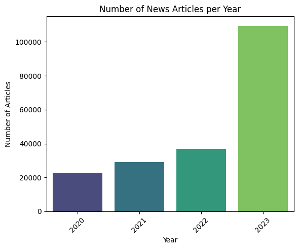

```python
# Count the number of articles per year
articles_per_year = news['year'].value_counts().sort_index().reset_index()
articles_per_year.columns = ['Year', 'Number of Articles']  # Renaming columns for clarity

# Plot using seaborn
plt.figure(figsize=(6, 5))
sns.barplot(x='Year', y='Number of Articles', data=articles_per_year, palette='viridis')

plt.title('Number of News Articles per Year')
plt.xlabel('Year')
plt.ylabel('Number of Articles')
plt.xticks(rotation=45)
plt.tight_layout()

plt.show()
```

### 2. Month

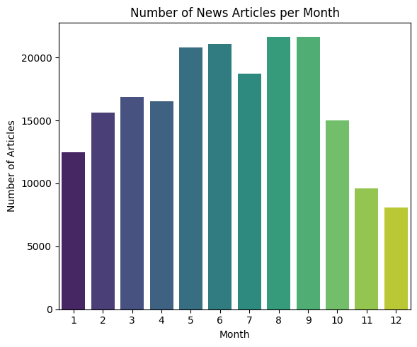

```python
# Count the number of articles per year
articles_per_month = news['month'].value_counts().sort_index().reset_index()
articles_per_month.columns = ['Month', 'Number of Articles']  # Renaming columns for clarity

# Plot using seaborn
plt.figure(figsize=(6, 5))
sns.barplot(x='Month', y='Number of Articles', data=articles_per_month, palette='viridis')

plt.title('Number of News Articles per Month')
plt.xlabel('Month')
plt.ylabel('Number of Articles')
# plt.xticks(rotation=45)
plt.tight_layout()

plt.show()
```

### 3. Year-Month

```python
monthly_counts = news.groupby(['year', 'month']).size().reset_index(name = 'count')
monthly_counts.head()
```

|  | year | month | count |
| --- | --- | --- | --- |
| 0 | 2020 | 1 | 1999 |
| 1 | 2020 | 2 | 1834 |
| 2 | 2020 | 3 | 2028 |
| 3 | 2020 | 4 | 1949 |
| 4 | 2020 | 5 | 1860 |

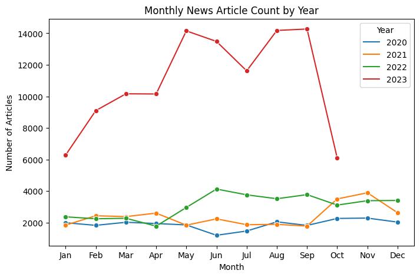

```python
# Create the line plot
custom_colors = ["#1f77b4", "#ff7f0e", "#2ca02c", "#d62728", "#9467bd", "#8c564b", "#e377c2", "#7f7f7f", "#bcbd22", "#17becf"]

plt.figure(figsize=(8, 5))
sns.lineplot(data=monthly_counts, x='month', y='count', hue='year', marker='o', palette=custom_colors)
plt.xlabel('Month')
plt.ylabel('Number of Articles')
plt.title('Monthly News Article Count by Year')
plt.legend(title='Year')
plt.xticks(range(1, 13), ['Jan', 'Feb', 'Mar', 'Apr', 'May', 'Jun', 'Jul', 'Aug', 'Sep', 'Oct', 'Nov', 'Dec'])  # Month labels from 1 to 12
plt.show()
```